# iPSC Clustering : Yoav Data

## Topic model on the molecules data

Building the Structure Plot for the topic weights for the molecules data based on the individual specific effects (potential batch effects??)

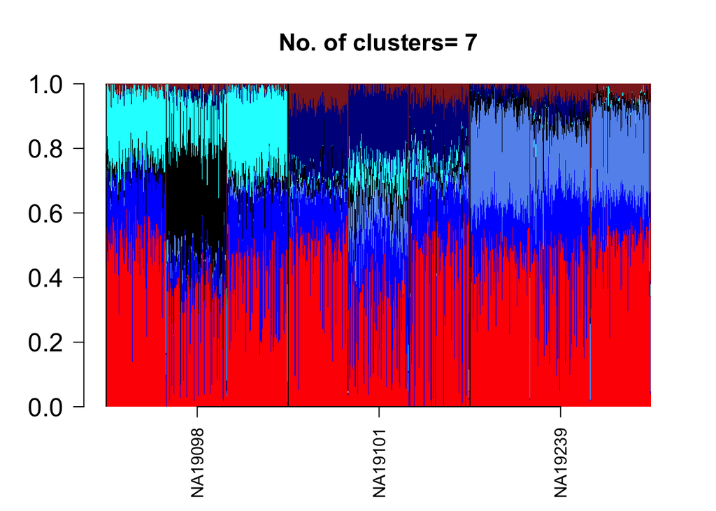

Building the Structure Plot for the topic weights for the molecules data based on the batches (further clarification needed what these are)…look up [JBlischak page](http://jdblischak.github.io/singleCellSeq/analysis/sum-counts-per-sample.html)

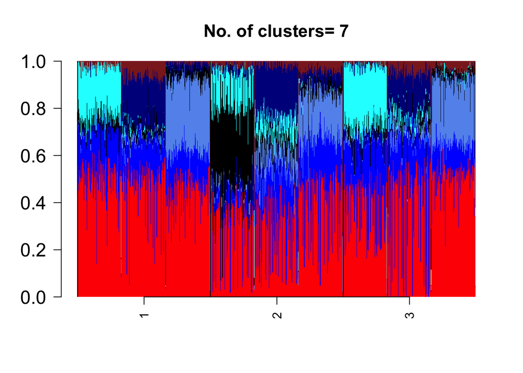

Building the Structure Plot for the topic weights for the molecules data based on the wells

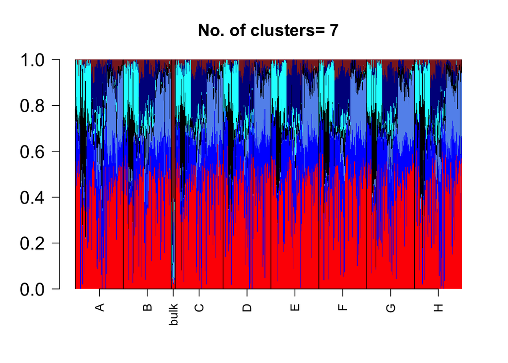